# Biostat 203B Homework 3

Due Feb 23 @ 11:59PM

Author

Load necessary libraries (you can add more as needed).

```r
library(arrow)
library(memuse)
library(pryr)
library(R.utils)
library(tidyverse)
```

Display your machine memory.

```r
memuse::Sys.meminfo()
```

In this exercise, we use tidyverse (ggplot2, dplyr, etc) to explore the [MIMIC-IV](https://mimic.mit.edu/docs/iv/) data introduced in [homework 1](https://ucla-biostat-203b.github.io/2024winter/hw/hw1/hw1.html) and to build a cohort of ICU stays.

## Q1. Visualizing patient trajectory

Visualizing a patient’s encounters in a health care system is a common task in clinical data analysis. In this question, we will visualize a patient’s ADT (admission-discharge-transfer) history and ICU vitals in the MIMIC-IV data.

### Q1.1 ADT history

Do a similar visualization for the patient with `subject_id` 10013310 using ggplot.

Hint: We need to pull information from data files `patients.csv.gz`, `admissions.csv.gz`, `transfers.csv.gz`, `labevents.csv.gz`, `procedures_icd.csv.gz`, `diagnoses_icd.csv.gz`, `d_icd_procedures.csv.gz`, and `d_icd_diagnoses.csv.gz`. For the big file `labevents.csv.gz`, use the Parquet format you generated in Homework 2. For reproducibility, make the Parquet folder `labevents_pq` available at the current working directory `hw3`, for example, by a symbolic link. Make your code reproducible.

```bash
ln -s /Users/zihengzhang/Downloads/203B/203b-hw/hw2/labevents_parquet \
/Users/zihengzhang/Downloads/203B/203b-hw/hw3/labevents_pq
```

```r
labevents_data <- arrow::open_dataset("./labevents_pq",
                                         format = "parquet")
```

```r
patient_id <- 10013310

race_info <- read_csv("~/mimic/hosp/admissions.csv.gz") |>
  filter(subject_id == patient_id) |>
  select(subject_id, race)
personal_info <- read_csv("~/mimic/hosp/patients.csv.gz") |>
  filter(subject_id == patient_id) |>
  select(subject_id, gender, anchor_age) |>
  rename(age = anchor_age) |>
  left_join(race_info, by = "subject_id") |>
  distinct()
diagonose_code_info <- read_csv("~/mimic/hosp/d_icd_diagnoses.csv.gz")
diagnose_info <- read_csv("~/mimic/hosp/diagnoses_icd.csv.gz") |>
  filter(subject_id == patient_id) |>
  select(-icd_version) |>
  filter(seq_num <= 3) |>
  left_join(diagonose_code_info, by = c("icd_code" = "icd_code")) |>
  select(-icd_version)
ADT_info <- read_csv("~/mimic/hosp/transfers.csv.gz") |>
  filter(subject_id == patient_id) |>
  select(subject_id, hadm_id, intime, outtime, eventtype, careunit) |>
  arrange(intime) |>
  mutate(ADT_Type = careunit) |>
  mutate(ADT_Type = ifelse(ADT_Type %in% c("Coronary Care Unit (CCU)",
                           "Neuro Surgical Intensive Care Unit (Neuro SICU)"),
                           "ICU/CCU", ADT_Type)) |>
  mutate(ADT_Type = ifelse(ADT_Type %in% c("Neuro Intermediate"), "Neuro",
                           ADT_Type))
lab_info <- labevents_data |>
  filter(subject_id == patient_id) |>
  select(subject_id, hadm_id, charttime) |>
  collect() |>
  distinct()


procedure_code_info <- read_csv("~/mimic/hosp/d_icd_procedures.csv.gz")
procedure_info <- read_csv("~/mimic/hosp/procedures_icd.csv.gz") |>
  filter(subject_id == patient_id) |>
  select(subject_id, hadm_id, chartdate, icd_code) |>
  mutate(chartdate = as.POSIXct(chartdate, format = "%Y-%m-%d %H:%M:%S")) |>
  left_join(procedure_code_info, by = c("icd_code" = "icd_code")) |>
  select(-icd_version) |>
  arrange(chartdate) |>
  mutate(short_title = str_split(long_title, "\\s+") %>% sapply(function(x)
    paste(x[1:3], collapse = " "))) |>
  distinct()
```

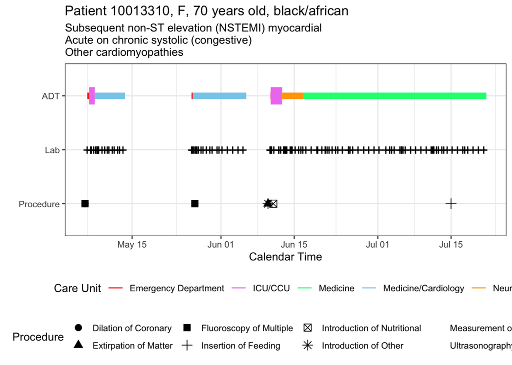

```r
title_text <- sprintf("Patient %d, %s, %d years old, %s",
                      personal_info$subject_id, personal_info$gender,
                      personal_info$age, tolower(personal_info$race))

top3_text <- diagnose_info |>
  slice(1:3) |>
  select(long_title) |>
  mutate(first_five_words = str_split(long_title, "\\s+") %>%
    sapply(function(x) {
      if (length(x) < 5) {
        paste(x, collapse = " ")
        } else {
          paste(x[1:5], collapse = " ")
          }
      })) |>
  pull(first_five_words)

subtitle_text <- sprintf("%s\n%s\n%s", top3_text[1], top3_text[2], top3_text[3])

empty_plot <- ggplot() +
  geom_blank() +
  scale_y_discrete(limits = c("Procedure", "Lab", "ADT")) +
  labs(x = "Calendar Time", title = title_text, subtitle = subtitle_text) +
  theme_bw()

ADT_plot <- empty_plot +
  geom_segment(data = ADT_info, aes(x = intime, xend = outtime, y = "ADT",
                                    yend = "ADT", color = ADT_Type,
                                    ),
               linewidth = ifelse(ADT_info$ADT_Type == "ICU/CCU", 8, 3)) +
  scale_color_manual(values = c("Emergency Department" =  "red",
                                "Medicine" = "springgreen",
                                "ICU/CCU" = "violet",
                                "Neuro" = "orange",
                                "Medicine/Cardiology" = "skyblue")) +
  labs(color = "Care Unit") +
  theme(legend.position = "bottom")

Lab_plot <- ADT_plot +
  geom_point(data = lab_info, aes(x = charttime, y = "Lab"),
             size = 5, shape = "+")

Procedure_plot <- Lab_plot +
  geom_point(data = procedure_info, aes(x = chartdate, y = "Procedure",
                                        shape = short_title), size = 3) +
  labs(shape = "Procedure", y = "") +
  theme(legend.position = "bottom", legend.box = "vertical")

plot(Procedure_plot)
```

**Answer:** This patient has been admitted to the hospital three times. Each admission results in the top 3 diagnoses. Therefore, for the subtitle, we select one of the admission records and displayed the top 3 diagnoses for that admission. Here we select admission record with `hadm_id` = 21243435 and we only display the first few words of the long title because the long title is too long.  
For the label of procedure, since the long title is too long, we only display the first three words of the long title. And since the shape palette can deal with a maximum of 6 discrete values in RStudio, we only display the first 6 procedures and the remaining two procedures are labeled with blank labels.

## Q2. ICU stays

`icustays.csv.gz` (https://mimic.mit.edu/docs/iv/modules/icu/icustays/) contains data about Intensive Care Units (ICU) stays. The first 10 lines are

```bash
zcat < ~/mimic/icu/icustays.csv.gz | head
```

```
subject_id,hadm_id,stay_id,first_careunit,last_careunit,intime,outtime,los
10000032,29079034,39553978,Medical Intensive Care Unit (MICU),Medical Intensive Care Unit (MICU),2180-07-23 14:00:00,2180-07-23 23:50:47,0.4102662037037037
10000980,26913865,39765666,Medical Intensive Care Unit (MICU),Medical Intensive Care Unit (MICU),2189-06-27 08:42:00,2189-06-27 20:38:27,0.4975347222222222
10001217,24597018,37067082,Surgical Intensive Care Unit (SICU),Surgical Intensive Care Unit (SICU),2157-11-20 19:18:02,2157-11-21 22:08:00,1.1180324074074075
10001217,27703517,34592300,Surgical Intensive Care Unit (SICU),Surgical Intensive Care Unit (SICU),2157-12-19 15:42:24,2157-12-20 14:27:41,0.9481134259259258
10001725,25563031,31205490,Medical/Surgical Intensive Care Unit (MICU/SICU),Medical/Surgical Intensive Care Unit (MICU/SICU),2110-04-11 15:52:22,2110-04-12 23:59:56,1.338587962962963
10001884,26184834,37510196,Medical Intensive Care Unit (MICU),Medical Intensive Care Unit (MICU),2131-01-11 04:20:05,2131-01-20 08:27:30,9.171817129629629
10002013,23581541,39060235,Cardiac Vascular Intensive Care Unit (CVICU),Cardiac Vascular Intensive Care Unit (CVICU),2160-05-18 10:00:53,2160-05-19 17:33:33,1.3143518518518518
10002155,20345487,32358465,Medical Intensive Care Unit (MICU),Medical Intensive Care Unit (MICU),2131-03-09 21:33:00,2131-03-10 18:09:21,0.8585763888888889
10002155,23822395,33685454,Coronary Care Unit (CCU),Coronary Care Unit (CCU),2129-08-04 12:45:00,2129-08-10 17:02:38,6.178912037037037
```

### Q2.1 Ingestion

Import `icustays.csv.gz` as a tibble `icustays_tble`.

```r
icustays_tble <- read_csv("~/mimic/icu/icustays.csv.gz")
```

### Q2.2 Summary and visualization

How many unique `subject_id`? Can a `subject_id` have multiple ICU stays? Summarize the number of ICU stays per `subject_id` by graphs.

```r
icustays_tble |> distinct(subject_id) |> count()
```

```
# A tibble: 1 × 1
      n
  <int>
1 50920
```

```r
icustays_tble |> count(subject_id)
```

```
# A tibble: 50,920 × 2
   subject_id     n
        <dbl> <int>
 1   10000032     1
 2   10000980     1
 3   10001217     2
 4   10001725     1
 5   10001884     1
 6   10002013     1
 7   10002155     3
 8   10002348     1
 9   10002428     4
10   10002430     1
# ℹ 50,910 more rows
```

**Answer:** There are 50920 unique `subject_id`. A `subject_id` can have multiple ICU stays.

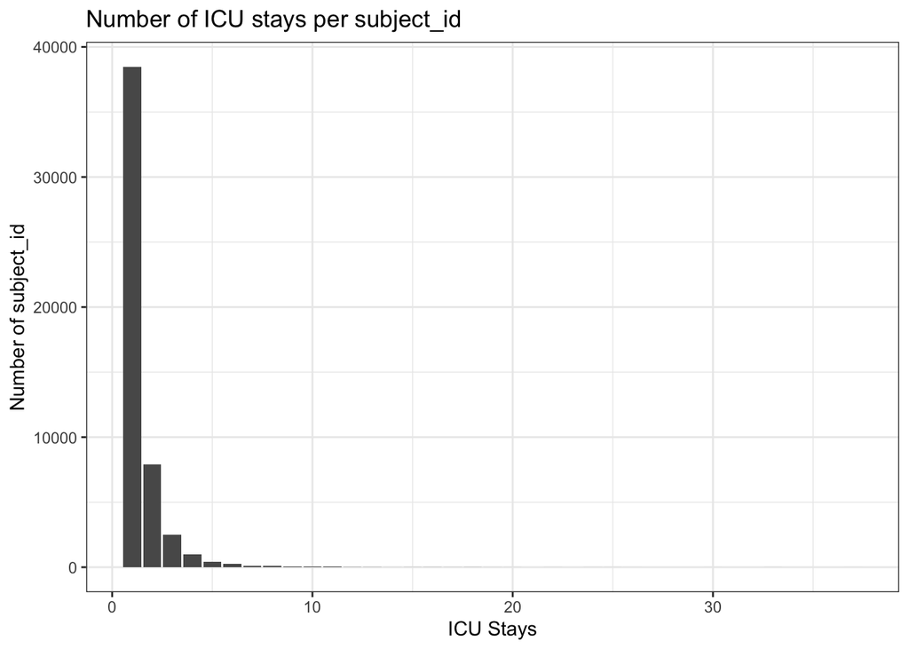

```r
icustays_tble |> count(subject_id) |> ggplot(aes(n)) + geom_bar() +
  labs(title = "Number of ICU stays per subject_id") + xlab("ICU Stays") +
  ylab("Number of subject_id") + theme_bw()
```

**Answer:** The number of ICU stays per `subject_id` is shown in the graph above. Most `subject_id` have 1 ICU stay, and the number of `subject_id` decreases as the number of ICU stays increases.

## Q3. `admissions` data

Information of the patients admitted into hospital is available in `admissions.csv.gz`. See https://mimic.mit.edu/docs/iv/modules/hosp/admissions/ for details of each field in this file. The first 10 lines are

```bash
zcat < ~/mimic/hosp/admissions.csv.gz | head
```

```
subject_id,hadm_id,admittime,dischtime,deathtime,admission_type,admit_provider_id,admission_location,discharge_location,insurance,language,marital_status,race,edregtime,edouttime,hospital_expire_flag
10000032,22595853,2180-05-06 22:23:00,2180-05-07 17:15:00,,URGENT,P874LG,TRANSFER FROM HOSPITAL,HOME,Other,ENGLISH,WIDOWED,WHITE,2180-05-06 19:17:00,2180-05-06 23:30:00,0
10000032,22841357,2180-06-26 18:27:00,2180-06-27 18:49:00,,EW EMER.,P09Q6Y,EMERGENCY ROOM,HOME,Medicaid,ENGLISH,WIDOWED,WHITE,2180-06-26 15:54:00,2180-06-26 21:31:00,0
10000032,25742920,2180-08-05 23:44:00,2180-08-07 17:50:00,,EW EMER.,P60CC5,EMERGENCY ROOM,HOSPICE,Medicaid,ENGLISH,WIDOWED,WHITE,2180-08-05 20:58:00,2180-08-06 01:44:00,0
10000032,29079034,2180-07-23 12:35:00,2180-07-25 17:55:00,,EW EMER.,P30KEH,EMERGENCY ROOM,HOME,Medicaid,ENGLISH,WIDOWED,WHITE,2180-07-23 05:54:00,2180-07-23 14:00:00,0
10000068,25022803,2160-03-03 23:16:00,2160-03-04 06:26:00,,EU OBSERVATION,P51VDL,EMERGENCY ROOM,,Other,ENGLISH,SINGLE,WHITE,2160-03-03 21:55:00,2160-03-04 06:26:00,0
10000084,23052089,2160-11-21 01:56:00,2160-11-25 14:52:00,,EW EMER.,P6957U,WALK-IN/SELF REFERRAL,HOME HEALTH CARE,Medicare,ENGLISH,MARRIED,WHITE,2160-11-20 20:36:00,2160-11-21 03:20:00,0
10000084,29888819,2160-12-28 05:11:00,2160-12-28 16:07:00,,EU OBSERVATION,P63AD6,PHYSICIAN REFERRAL,,Medicare,ENGLISH,MARRIED,WHITE,2160-12-27 18:32:00,2160-12-28 16:07:00,0
10000108,27250926,2163-09-27 23:17:00,2163-09-28 09:04:00,,EU OBSERVATION,P38XXV,EMERGENCY ROOM,,Other,ENGLISH,SINGLE,WHITE,2163-09-27 16:18:00,2163-09-28 09:04:00,0
10000117,22927623,2181-11-15 02:05:00,2181-11-15 14:52:00,,EU OBSERVATION,P2358X,EMERGENCY ROOM,,Other,ENGLISH,DIVORCED,WHITE,2181-11-14 21:51:00,2181-11-15 09:57:00,0
```

### Q3.1 Ingestion

Import `admissions.csv.gz` as a tibble `admissions_tble`.

```r
admissions_tble <- read_csv("~/mimic/hosp/admissions.csv.gz")
```

### Q3.2 Summary and visualization

Summarize the following information by graphics and explain any patterns you see.

- number of admissions per patient
- admission hour (anything unusual?)
- admission minute (anything unusual?)
- length of hospital stay (from admission to discharge) (anything unusual?)

According to the [MIMIC-IV documentation](https://mimic.mit.edu/docs/iv/about/concepts/#date-shifting),

> All dates in the database have been shifted to protect patient confidentiality. Dates will be internally consistent for the same patient, but randomly distributed in the future. Dates of birth which occur in the present time are not true dates of birth. Furthermore, dates of birth which occur before the year 1900 occur if the patient is older than 89. In these cases, the patient’s age at their first admission has been fixed to 300.

```r
admissions_tble |> distinct(subject_id) |> count()
```

```
# A tibble: 1 × 1
       n
   <int>
1 180733
```

```r
admissions_tble |> count(subject_id)
```

```
# A tibble: 180,733 × 2
   subject_id     n
        <dbl> <int>
 1   10000032     4
 2   10000068     1
 3   10000084     2
 4   10000108     1
 5   10000117     2
 6   10000248     1
 7   10000280     1
 8   10000560     1
 9   10000635     1
10   10000719     1
# ℹ 180,723 more rows
```

**Answer:** There are 180733 unique `subject_id`. A `subject_id` can have multiple admissions.

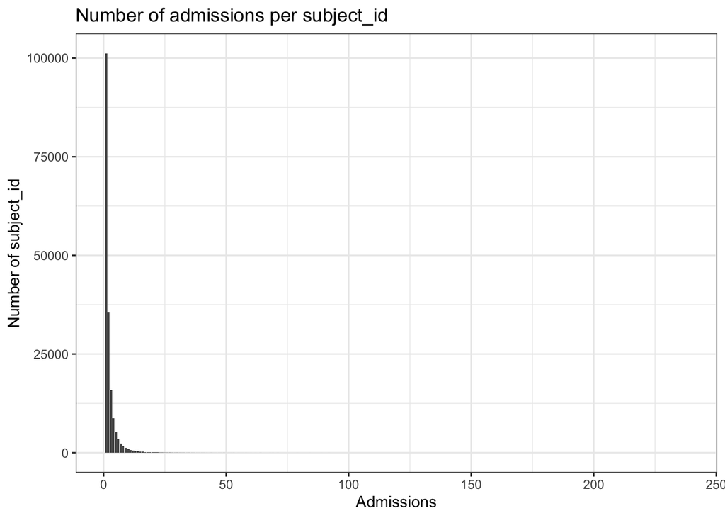

```r
admissions_tble |> count(subject_id) |> ggplot(aes(n)) + geom_bar() +
  labs(title = "Number of admissions per subject_id") + xlab("Admissions") +
  ylab("Number of subject_id") + theme_bw()
```

**Answer:** The number of admissions per `subject_id` is shown in the graph above. Most `subject_id` have 1 admission, and the number of `subject_id` decreases as the number of admissions increases.

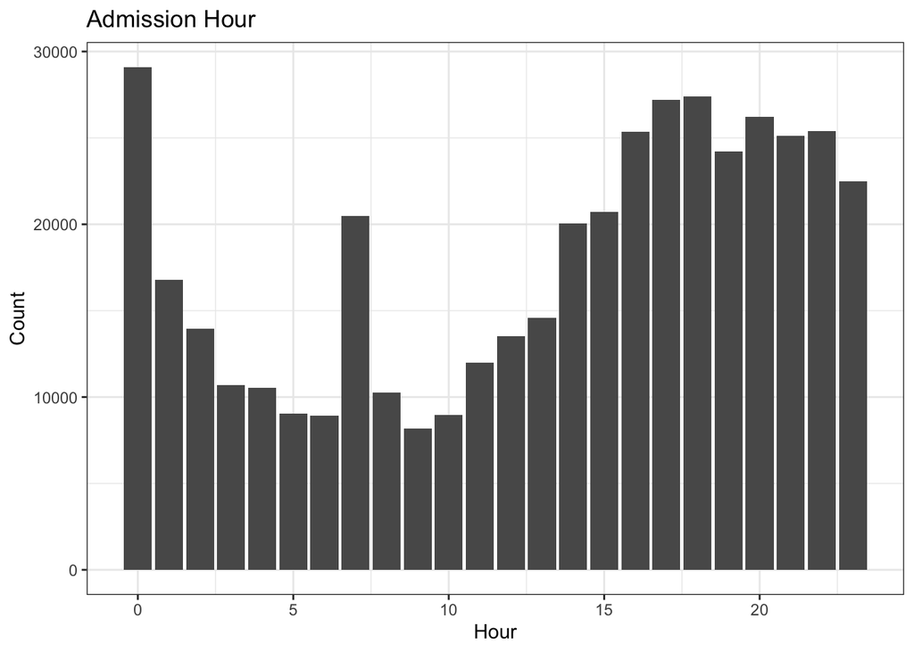

```r
admissions_hour <- hour(admissions_tble$admittime) |> as_tibble()
ggplot(data = admissions_hour, aes(value)) + geom_bar() +
  labs(title = "Admission Hour") + xlab("Hour") + ylab("Count") + theme_bw()
```

**Answer:** The admission hour is shown in the graph above. It seems there is something unusual. The number of admissions is highest at midnight, gradually decreasing over time. However, there is a sudden increase in admissions at 7AM. Then, as time progresses, the number of admissions gradually increases. The evening and night are the peak admission times within a day, with the overall situation being relatively balanced.

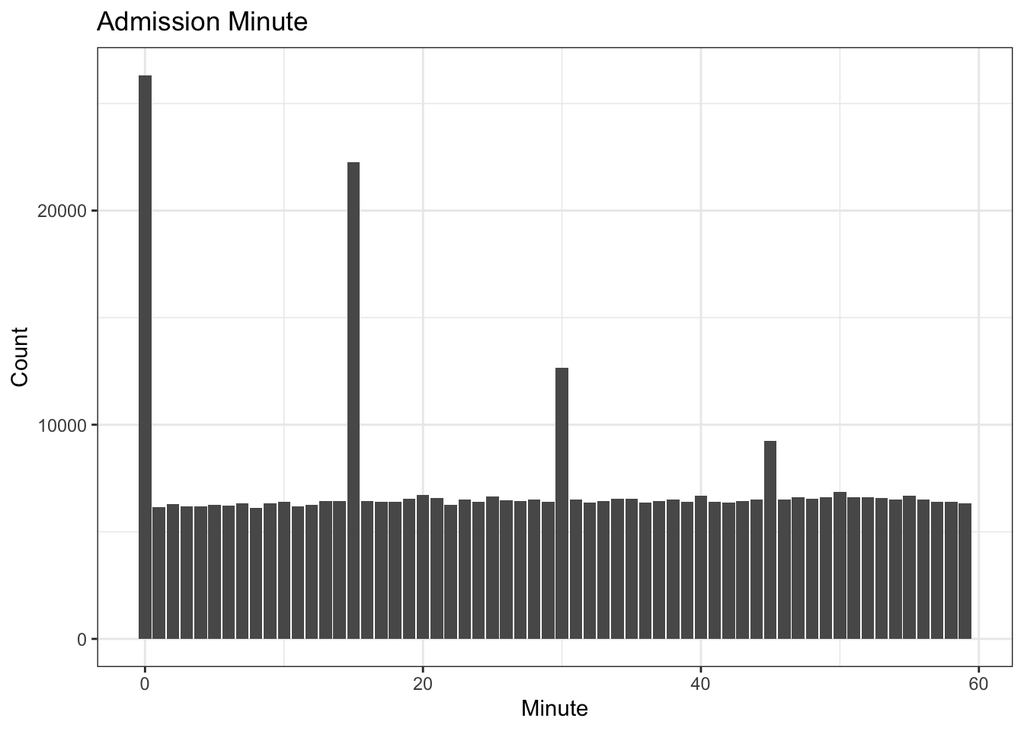

```r
admissions_minute <- minute(admissions_tble$admittime) |> as_tibble()
ggplot(data = admissions_minute, aes(value)) + geom_bar() +
  labs(title = "Admission Minute") + xlab("Minute") + ylab("Count") + theme_bw()
```

**Answer:** The admission minute is shown in the graph above. There are very clear unusual patterns. There are significant peaks in admissions at the top of the hour, 15 minutes past, 30 minutes past, and 45 minutes past the hour. At other times, the number of admissions is relatively evenly distributed.

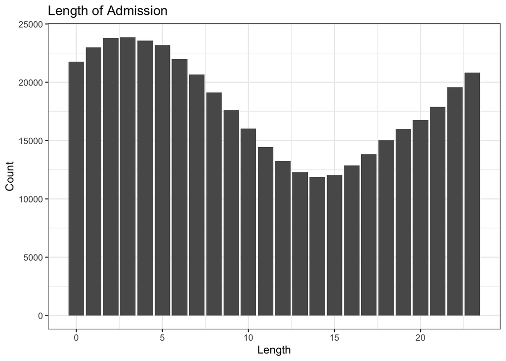

```r
admissions_length <- interval(admissions_tble$dischtime,
                            admissions_tble$admittime) |> hour() |> as_tibble()
admissions_length |> ggplot(aes(value)) + geom_bar() +
  labs(title = "Length of Admission ") + xlab("Length") + ylab("Count") + theme_bw()
```

**Answer:** The length of hospital stay is shown in the graph above. It appears there is some unusual pattern. The most common length of hospital stay is around 3 hours. As the length of hospital stay increases, the frequency gradually decreases. The least common length is around 14 hours. However, as the length of hospital stay continues to increase, the frequency begins to gradually rise again. The longest length is around 24 hours.

## Q4. `patients` data

Patient information is available in `patients.csv.gz`. See https://mimic.mit.edu/docs/iv/modules/hosp/patients/ for details of each field in this file. The first 10 lines are

```bash
zcat < ~/mimic/hosp/patients.csv.gz | head
```

```
subject_id,gender,anchor_age,anchor_year,anchor_year_group,dod
10000032,F,52,2180,2014 - 2016,2180-09-09
10000048,F,23,2126,2008 - 2010,
10000068,F,19,2160,2008 - 2010,
10000084,M,72,2160,2017 - 2019,2161-02-13
10000102,F,27,2136,2008 - 2010,
10000108,M,25,2163,2014 - 2016,
10000115,M,24,2154,2017 - 2019,
10000117,F,48,2174,2008 - 2010,
10000178,F,59,2157,2017 - 2019,
```

### Q4.1 Ingestion

Import `patients.csv.gz` (https://mimic.mit.edu/docs/iv/modules/hosp/patients/) as a tibble `patients_tble`.

```r
patients_tble <- read_csv("~/mimic/hosp/patients.csv.gz")
```

### Q4.2 Summary and visualization

Summarize variables `gender` and `anchor_age` by graphics, and explain any patterns you see.

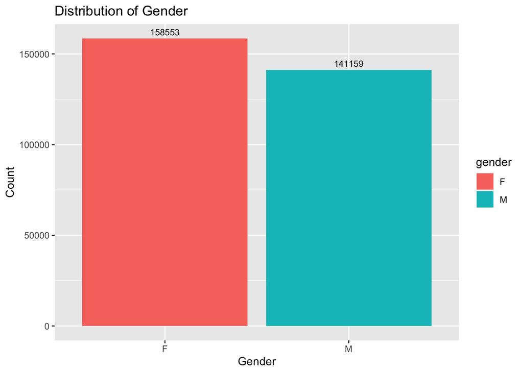

```r
ggplot(patients_tble, aes(x = gender, fill = gender)) +
  geom_bar() +
  geom_text(stat='count', aes(label=after_stat(count)),
            vjust=-0.5, color='black', size=3) +
  labs(title = "Distribution of Gender",
       x = "Gender",
       y = "Count")
```

**Answer:** The number of female patients is slightly higher than the number of male patients. 158,553 vs 141,159.

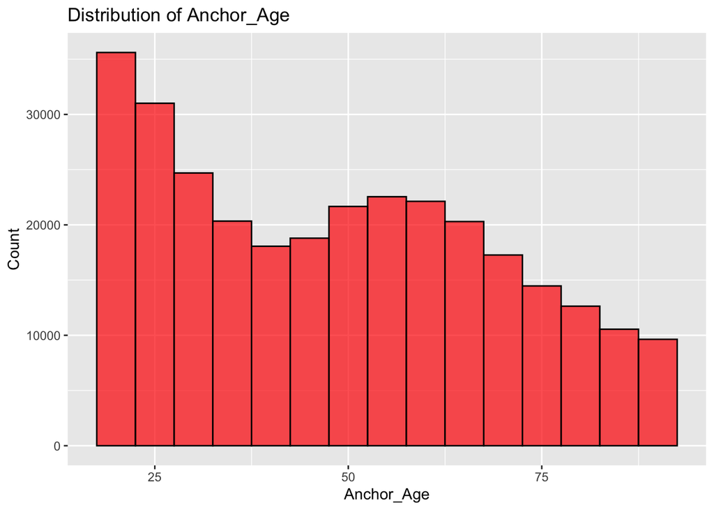

```r
ggplot(patients_tble, aes(x = anchor_age)) +
  geom_histogram(binwidth = 5, fill = "red", color = "black", alpha = 0.7) +
  labs(title = "Distribution of Anchor_Age",
       x = "Anchor_Age",
       y = "Count")
```

**Answer:** The distribution of `anchor_age` is shown in the graph above. The number of patients is highest in the youngest age group, around 20 years old, and the number of patients firstly decreases and then increases as the age increases. There is another peak in the age group 55. And then the number of patients gradually decreases as the age increases.

## Q5. Lab results

`labevents.csv.gz` (https://mimic.mit.edu/docs/iv/modules/hosp/labevents/) contains all laboratory measurements for patients. The first 10 lines are

```bash
zcat < ~/mimic/hosp/labevents.csv.gz | head
```

```
labevent_id,subject_id,hadm_id,specimen_id,itemid,order_provider_id,charttime,storetime,value,valuenum,valueuom,ref_range_lower,ref_range_upper,flag,priority,comments
1,10000032,,45421181,51237,P28Z0X,2180-03-23 11:51:00,2180-03-23 15:15:00,1.4,1.4,,0.9,1.1,abnormal,ROUTINE,
2,10000032,,45421181,51274,P28Z0X,2180-03-23 11:51:00,2180-03-23 15:15:00,___,15.1,sec,9.4,12.5,abnormal,ROUTINE,VERIFIED.
3,10000032,,52958335,50853,P28Z0X,2180-03-23 11:51:00,2180-03-25 11:06:00,___,15,ng/mL,30,60,abnormal,ROUTINE,NEW ASSAY IN USE ___: DETECTS D2 AND D3 25-OH ACCURATELY.
4,10000032,,52958335,50861,P28Z0X,2180-03-23 11:51:00,2180-03-23 16:40:00,102,102,IU/L,0,40,abnormal,ROUTINE,
5,10000032,,52958335,50862,P28Z0X,2180-03-23 11:51:00,2180-03-23 16:40:00,3.3,3.3,g/dL,3.5,5.2,abnormal,ROUTINE,
6,10000032,,52958335,50863,P28Z0X,2180-03-23 11:51:00,2180-03-23 16:40:00,109,109,IU/L,35,105,abnormal,ROUTINE,
7,10000032,,52958335,50864,P28Z0X,2180-03-23 11:51:00,2180-03-23 16:40:00,___,8,ng/mL,0,8.7,,ROUTINE,MEASURED BY ___.
8,10000032,,52958335,50868,P28Z0X,2180-03-23 11:51:00,2180-03-23 16:40:00,12,12,mEq/L,8,20,,ROUTINE,
9,10000032,,52958335,50878,P28Z0X,2180-03-23 11:51:00,2180-03-23 16:40:00,143,143,IU/L,0,40,abnormal,ROUTINE,
```

`d_labitems.csv.gz` (https://mimic.mit.edu/docs/iv/modules/hosp/d_labitems/) is the dictionary of lab measurements.

```bash
zcat < ~/mimic/hosp/d_labitems.csv.gz | head
```

```
itemid,label,fluid,category
50801,Alveolar-arterial Gradient,Blood,Blood Gas
50802,Base Excess,Blood,Blood Gas
50803,"Calculated Bicarbonate, Whole Blood",Blood,Blood Gas
50804,Calculated Total CO2,Blood,Blood Gas
50805,Carboxyhemoglobin,Blood,Blood Gas
50806,"Chloride, Whole Blood",Blood,Blood Gas
50808,Free Calcium,Blood,Blood Gas
50809,Glucose,Blood,Blood Gas
50810,"Hematocrit, Calculated",Blood,Blood Gas
```

We are interested in the lab measurements of creatinine (50912), potassium (50971), sodium (50983), chloride (50902), bicarbonate (50882), hematocrit (51221), white blood cell count (51301), and glucose (50931). Retrieve a subset of `labevents.csv.gz` that only containing these items for the patients in `icustays_tble`. Further restrict to the last available measurement (by `storetime`) before the ICU stay. The final `labevents_tble` should have one row per ICU stay and columns for each lab measurement.

Hint: Use the Parquet format you generated in Homework 2. For reproducibility, make `labevents_pq` folder available at the current working directory `hw3`, for example, by a symbolic link.

```r
filtered_labevents_parquet <- arrow::open_dataset("./labevents_pq",
                                         format = "parquet") |>
  dplyr::filter(itemid %in% c(50912, 50971, 50983, 50902,
                              50882, 51221, 51301, 50931)) |>
  dplyr::filter(subject_id %in% unique(icustays_tble$subject_id)) |>
  dplyr::filter(hadm_id %in% unique(icustays_tble$hadm_id)) |>
  dplyr::collect()
```

```r
d_labitems <- read_csv("~/mimic/hosp/d_labitems.csv.gz")
d_item_subset <- d_labitems %>%
  select(itemid, label)
icustays_tble_subset <- select(icustays_tble, subject_id, stay_id, intime)

labevents_tble <- arrow::open_dataset("./labevents_pq",
                                         format = "parquet") |>
  dplyr::filter(itemid %in% c(50912, 50971, 50983, 50902,
                              50882, 51221, 51301, 50931)) |>
  dplyr::select(subject_id, itemid, valuenum, storetime) |>
  arrange(subject_id, itemid) |>
  dplyr::collect() |>
  semi_join(icustays_tble, by = c("subject_id")) |>
  left_join(d_item_subset, by = c("itemid")) |>
  left_join(icustays_tble_subset, by = c("subject_id")) |>
  filter(storetime < intime) |>
  group_by(subject_id, label, stay_id) |>
  summarise(finalvalue = last(valuenum)) |>
  spread(label, finalvalue)
labevents_tble
```

```
# A tibble: 68,467 × 10
# Groups:   subject_id [47,305]
   subject_id  stay_id Bicarbonate Chloride Creatinine Glucose Hematocrit
        <dbl>    <dbl>       <dbl>    <dbl>      <dbl>   <dbl>      <dbl>
 1   10000032 39553978          25       95        0.7     102       41.1
 2   10000980 39765666          21      109        2.3      89       27.3
 3   10001217 34592300          30      104        0.5      87       37.4
 4   10001217 37067082          22      108        0.6     112       38.1
 5   10001725 31205490          NA       98       NA        NA       NA
 6   10001884 37510196          30       88        1.1     141       39.7
 7   10002013 39060235          24      102        0.9     288       34.9
 8   10002155 31090461          23       98        2.8     117       25.5
 9   10002155 32358465          26       85        1.4     133       22.4
10   10002155 33685454          24      105        1.1     138       39.7
# ℹ 68,457 more rows
# ℹ 3 more variables: Potassium <dbl>, Sodium <dbl>, `White Blood Cells` <dbl>
```

## Q6. Vitals from charted events

`chartevents.csv.gz` (https://mimic.mit.edu/docs/iv/modules/icu/chartevents/) contains all the charted data available for a patient. During their ICU stay, the primary repository of a patient’s information is their electronic chart. The `itemid` variable indicates a single measurement type in the database. The `value` variable is the value measured for `itemid`. The first 10 lines of `chartevents.csv.gz` are

```bash
zcat < ~/mimic/icu/chartevents.csv.gz | head
```

[output not shown]

`d_items.csv.gz` (https://mimic.mit.edu/docs/iv/modules/icu/d_items/) is the dictionary for the `itemid` in `chartevents.csv.gz`.

```bash
zcat < ~/mimic/icu/d_items.csv.gz | head
```

[output not shown]

We are interested in the vitals for ICU patients: heart rate (220045), systolic non-invasive blood pressure (220179), diastolic non-invasive blood pressure (220180), body temperature in Fahrenheit (223761), and respiratory rate (220210). Retrieve a subset of `chartevents.csv.gz` only containing these items for the patients in `icustays_tble`. Further restrict to the first vital measurement within the ICU stay. The final `chartevents_tble` should have one row per ICU stay and columns for each vital measurement.

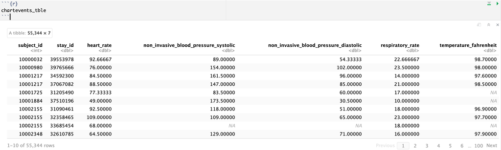

Hint: Use the Parquet format you generated in Homework 2. For reproducibility, make `chartevents_pq` folder available at the current working directory, for example, by a symbolic link.

## Q7. Putting things together

Let us create a tibble `mimic_icu_cohort` for all ICU stays, where rows are all ICU stays of adults (age at `intime` >= 18) and columns contain at least following variables

- all variables in `icustays_tble`
- all variables in `admissions_tble`
- all variables in `patients_tble`
- the last lab measurements before the ICU stay in `labevents_tble`
- the first vital measurements during the ICU stay in `chartevents_tble`

The final `mimic_icu_cohort` should have one row per ICU stay and columns for each variable.

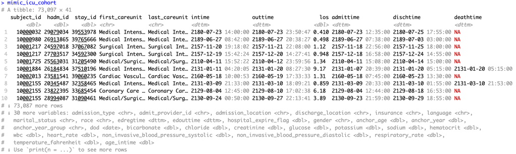

## Q8. Exploratory data analysis (EDA)

Summarize the following information about the ICU stay cohort `mimic_icu_cohort` using appropriate numerics or graphs:

- Length of ICU stay `los` vs demographic variables (race, insurance, marital_status, gender, age at intime)
- Length of ICU stay `los` vs the last available lab measurements before ICU stay
- Length of ICU stay `los` vs the average vital measurements within the first hour of ICU stay
- Length of ICU stay `los` vs first ICU unit